# Notebook

```python
import numpy as np
pi = np.pi
import matplotlib.pyplot as plt
import matplotlib.cm as cm
import os
import IPython
import scipy.io
from scipy.fftpack import dst
import scipy.stats as ss
import scipy.constants

%matplotlib inline

import sys
sys.path.insert(0,"C:\RPLabCode\ImageAnalysisofParticlesandMembranes")
import cveD
```

The timestamp from the DVC camera says that exposure took 119.81ms and transfer took 119.81ms, so I am assuming the sum for dt. However, this seems a little dubious, as that frame rate would take 117 seconds to record the 489 frames. I don't think this is what the software was set to do (seems slow by a factor of two).

```python
directory = 'F:\Mike\Rheology\Glycerol\water_Spet12_2014_scopeB'
dt = (0.11981 + 0.11981)
scale = 0.123
```

```python
filename = 'h2o1.mat'
Data = cveD.getData(directory + '\\' + filename)
objs_link = Data['objs_link']
```

```python
import scipy.ndimage as nd
```

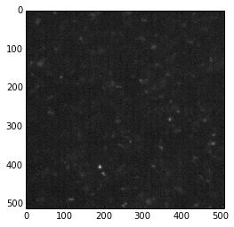

```python
im = nd.imread(directory + '\\' + 'h2o1.png')
#plt.figure()
plt.imshow(im,cmap=cm.gray)
```

I do worry a little that the signal to noise in these images isn't that good and that the tracking may therefore be producing ghost particles.

## Particle Tracks

I am going to limit consideration to tracks at least 100 frames long.

```python
tracks = (np.unique(objs_link[5,:]))
trackid = np.arange(1,tracks[-1] + 1)
length = np.bincount(objs_link[5,:].astype(int))
keepers = length > 100
longTracks = trackid[keepers[1:]].astype(int)
```

```python
longTracks.size
```

```
86
```

### Track visualization

Here are all 86 tracks of length > 100 frames

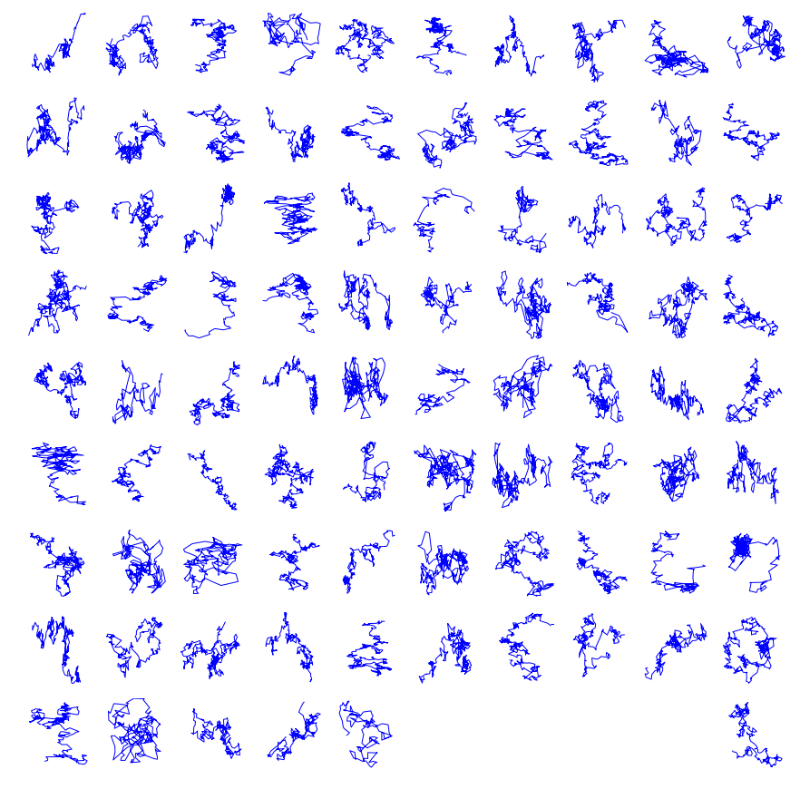

```python
plt.figure(figsize=(15,15))
for n in np.arange(0,86):
    plt.subplot(9,10,n)
    plt.plot(objs_link[0,objs_link[5,:]==longTracks[n]],objs_link[1,objs_link[5,:]==longTracks[n]])
    plt.axis('off')
```

## Calculate CVE based diffusion estimate and test validity

Here I will compute D for each particle, first from dx and then from dy (should this be done for $\sqrt{x^2 + y^2}$ instead?)

I will also compute a p value to test whether the track is consistent with a freely diffusing particle

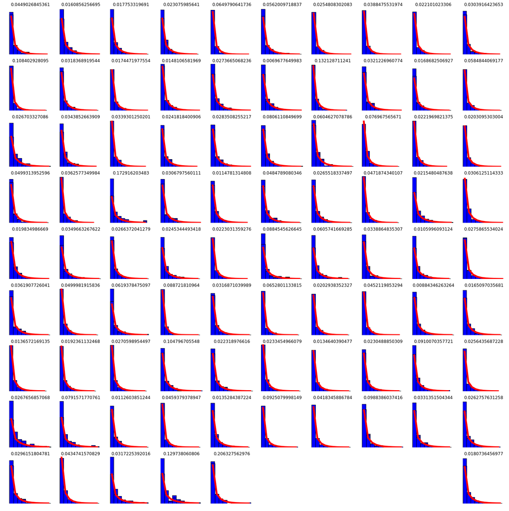

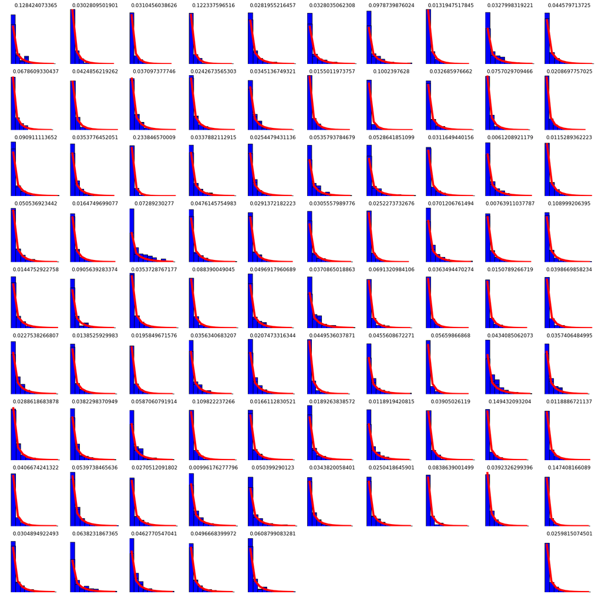

```python
D = np.zeros(2*longTracks.size)
localizationVariance = np.zeros(2*longTracks.size)
varianceD = np.zeros(2*longTracks.size)
SNR = np.zeros(2*longTracks.size)
p = np.zeros(2*longTracks.size)
X2 = np.zeros(2*longTracks.size)
plt.figure(figsize=(25,25))
for i in np.arange(0,longTracks.size):
    plt.subplot(9,10,i)
    x = objs_link[0,objs_link[5,:]==longTracks[i]]
    [D[i], localizationVariance[i], varianceD[i], SNR[i]], Pxk = cveD.cveD(x,dt, scale)
    theoryPxk = cveD.theoryP(D[i], dt, localizationVariance[i], Pxk.size)
    n, bins, patches = plt.hist(Pxk/theoryPxk, 10, normed=True)
    p[i], X2[i] = cveD.gammaChiSquared(n,bins)
    plt.title(p[i])
    plt.axis('off')

plt.figure(figsize=(25,25))
for i in np.arange(0,longTracks.size):
    plt.subplot(9,10,i)
    y = objs_link[1,objs_link[5,:]==longTracks[i]]
    [D[i+longTracks.size], localizationVariance[i+longTracks.size], varianceD[i+longTracks.size], SNR[i+longTracks.size]], Pxk = cveD.cveD(y,dt, scale)
    theoryPxk = cveD.theoryP(D[i+longTracks.size], dt, localizationVariance[i+longTracks.size], Pxk.size)
    n, bins, patches = plt.hist(Pxk/theoryPxk, 10, normed=True)
    p[i+longTracks.size], X2[i+longTracks.size] = cveD.gammaChiSquared(n,bins)
    plt.title(p[i+longTracks.size])
    plt.axis('off')
```

## Validity of tracking and model

Take a look at the values of the signal to noise ratio for tracking and the p value for model validity. SNR should be > 1 and p should be as low as possible

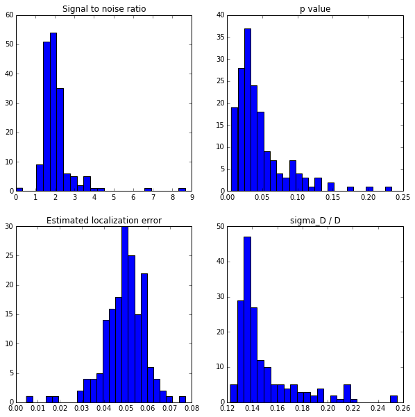

```python
plt.figure(figsize=(10,10))
plt.subplot(2,2,1)
plt.hist(np.nan_to_num(SNR),25)
plt.title('Signal to noise ratio')
plt.subplot(2,2,2)
plt.title('p value')
plt.hist(p,25)
plt.subplot(2,2,3)
plt.hist(np.sqrt(np.abs(localizationVariance)),25)
plt.title('Estimated localization error')
plt.subplot(2,2,4)
plt.hist(np.sqrt(varianceD)/D,25)
plt.title('sigma_D / D')
plt.show()
```

Both metrics look pretty good for a large number of particles. The localization error is on par with the particle size, which is a little disturbing, and there is a significant percentage of error in D.

Let's choose to restrict ourselves to SNR > 1.5 and p < 0.05.

The viscosity can be computed as $\eta = \frac{k_BT}{6\pi DR}$ and should $\approx 1$cP for water at room temperature

In the present situation, R is 20nm and T is roughly 25C

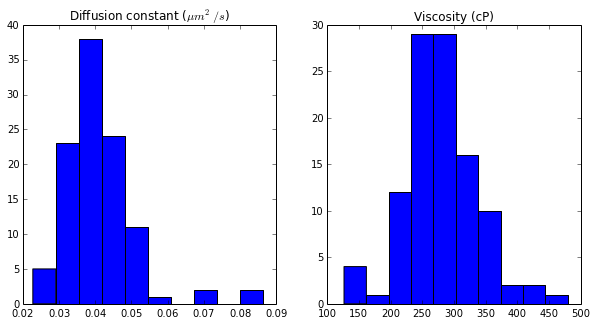

```
(0.040784902177272181, 280.13064438483298)
3.36152395012
```

```python
keepers = np.logical_and(np.nan_to_num(SNR)>1.5, p<0.05)
keepDeez = D[keepers]
plt.figure(figsize=(10,5))
plt.subplot(1,2,1)
plt.hist(keepDeez,10)
plt.title(r'Diffusion constant ($\mu m^2 / s$)')
plt.subplot(1,2,2)
plt.hist(cveD.D2eta(keepDeez,0.02,25),10)
plt.title('Viscosity (cP)')
plt.show()
print(np.mean(keepDeez),np.mean(cveD.D2eta(keepDeez,0.02,25)))
print(np.sqrt(np.mean(varianceD[keepers]))/np.mean(keepDeez**2))
```

This is high by a factor of about 300.

Using `msdtr_rp(obj, 1/(0.11981*2),0.123) and msdanalze_rp(msd, 0.01, 1)` gives an answer that is too high by a factor of about 400, which is very sensitive to the percentage of track used

It is unlikely that the uncertainty about the frame rate could account for this, as the effect should be linear for that.

The equation used in `cveD.D2eta()` appears to be correct, with the proper adjustments for reading R in $\mu m$, D in $\frac{\mu m^2 }{s}$, and T in $^{\circ}$C

## Track simulated with `simtrack()`

Used RP's `simtrack(1,128,1000,0,255,10,1,0)` to simulate a 2D random walk of one particle, with 1000 frames of size 128x128, 0 noise, intesity 255, width 10, and walk distribution width 1.

Running `msd_tr_rp(data, 1,1)` (fps=1, scale=1um/pix) and `msdanalyze_rp(msd,0.1,1)` (cutoff at 10%) yields D = 0.502 $\mu m^2 /s$

```python
temp = cveD.getData('F:\Mike\Rheology\simulatedTrack.mat')
x = np.squeeze(temp['x'])
y = np.squeeze(temp['y'])
```

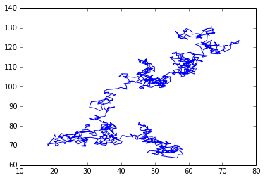

```python
plt.plot(x,y)
plt.show()
```

```python
dt = 1. # fps = 1/dt = 1
scale = 1.
```

```
(0.0071780974386538984, 0.9999999999998106)
0.399744910446
```

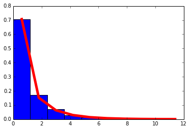

```python
[simD, simlocalizationVariance, simvarianceD, simSNR], simPxk = cveD.cveD(np.sqrt(x**2+y**2),dt, scale)
simtheoryPxk = cveD.theoryP(simD, dt, simlocalizationVariance, simPxk.size)
simn, simbins, simpatches = plt.hist(simPxk/simtheoryPxk, 10, normed=True)
simp, simX2 = cveD.gammaChiSquared(simn,simbins)
print(simp,simX2)
print(np.sqrt(simlocalizationVariance))
```

```python
simD
```

```
0.56231831199453342
```

The two methods seem consistent; the problem could be with `D2eta()`, or it could be bad data and or poor tracking. This would be a little unsettling, however, as the $\chi^2$ test is indicating consistency with a freely diffusing particle.

## New Data - 1$\mu m$ beads

I think that what was going on was that the beads were too dense and moving more rapidly than could be tracked at that frame rate. Therefore, I took some new data of 1$\mu m$ beads in water at room temperature. Since the fluorescence was a little weak and bleaching, I opted to collect data in brightfield, which looked like it had superior signal to noise over the fluorescence.

The software implied that it was going to take images at 250 ms intervals and the scope has a scale factor of 0.123 $m / $pix

I also noticed a lot of drift, so I will try to account for that by subtracting the mean particle position from each track.

```python
directory = 'F:\Mike\Rheology\Glycerol\water_Sept15_2014_scopeB'
dt = (0.250)
scale = 0.123
```

```python
filename = '1umBeadsBrightField.mat'
Data = cveD.getData(directory + '\\' + filename)
objs_link = Data['objs_link']
```

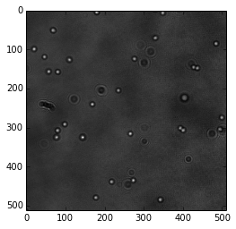

```python
im = nd.imread(directory + '\\' + 'stillImage.png')
#plt.figure()
plt.imshow(im,cmap=cm.gray)
```

There are far fewer particles in this data set, so I will be less picky about keeping short ones.

```python
tracks = (np.unique(objs_link[5,:]))
trackid = np.arange(1,tracks[-1] + 1)
length = np.bincount(objs_link[5,:].astype(int))
keepers = length > 50
longTracks = trackid[keepers[1:]].astype(int)

longTracks.size
```

```
8
```

```python
np.unique(objs_link[4,:])
```

```
array([   1.,    2.,    3.,    4.,    5.,    6.,    7.,    8.,    9.,
         10.,   11.,   12.,   13.,   14.,   15.,   16.,   17.,   18.,
         19.,   20.,   21.,   22.,   23.,   24.,   25.,   26.,   27.,
         28.,   29.,   30.,   31.,   32.,   33.,   34.,   35.,   36.,
         37.,   38.,   39.,   40.,   41.,   42.,   43.,   44.,   45.,
         46.,   47.,   48.,   49.,   50.,   51.,   52.,   53.,   54.,
         55.,   56.,   57.,   58.,   59.,   60.,   61.,   62.,   63.,
         64.,   65.,   66.,   67.,   68.,   69.,   70.,   71.,   72.,
         73.,   74.,   75.,   76.,   77.,   78.,   79.,   80.,   81.,
         82.,   83.,   84.,   85.,   86.,   87.,   88.,   89.,   90.,
         91.,   92.,   93.,   94.,   95.,   96.,   97.,   98.,   99.,
        100.,  101.,  102.,  103.,  104.,  105.,  106.,  107.,  108.,
        109.,  110.,  111.,  112.,  113.,  114.,  115.,  116.,  117.,
        118.,  119.,  120.,  121.,  122.,  123.,  124.,  125.,  126.,
        127.,  128.,  129.,  130.,  131.,  132.,  133.,  134.,  135.,
        136.,  137.,  138.,  139.,  140.,  141.,  142.,  143.,  144.,
        145.,  146.,  147.,  148.,  149.,  150.,  151.,  152.,  153.,
        154.,  155.,  156.,  157.,  158.,  159.,  160.,  161.,  162.,
        163.,  164.])
```

The camera was supposed to take 59 seconds of images at 250ms intervals. This should yield 236 frames, but there are only 164. ???

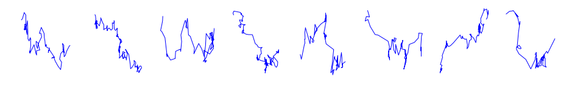

```python
plt.figure(figsize=(16,2))
for n in np.arange(0,longTracks.size):
    plt.subplot(1,8,n)
    plt.plot(objs_link[0,objs_link[5,:]==longTracks[n]],objs_link[1,objs_link[5,:]==longTracks[n]])
    plt.axis('off')
```

They are definitely drifting, so I will attempt to compensate:

`keep = np.zeros((2,trackid.size)) for n in np.arange(0,164): for m in np.arange(0,trackid.size): condition = objs_link[0,np.logical_and(objs_link[4,:]==n, objs_link[5,:].astype(int) == trackid[m])] # is track m present in frame n? if condition.size==0: # if not, place nan in this spot keep[0,m] = np.nan keep[1,m] = np.nan else: # if so, grab the x and y value of track m keep[0,m] = objs_link[0,np.logical_and(objs_link[4,:]==n, objs_link[5,:].astype(int) == trackid[m])] keep[1,m] = objs_link[1,np.logical_and(objs_link[4,:]==n, objs_link[5,:].astype(int) == trackid[m])] xymean = np.nanmean(keep,1) #mean x and y for frame n objs_link[0,objs_link[4,:]==n] -= xymean[0] objs_link[1,objs_link[4,:]==n] -= xymean[1]`

`plt.figure(figsize=(16,2)) for n in np.arange(0,longTracks.size): plt.subplot(1,8,n) plt.plot(objs_link[0,objs_link[5,:]==longTracks[n]],objs_link[1,objs_link[5,:]==longTracks[n]]) plt.axis('off')`

That didn't really work so well, so I will leave the tracks as they are

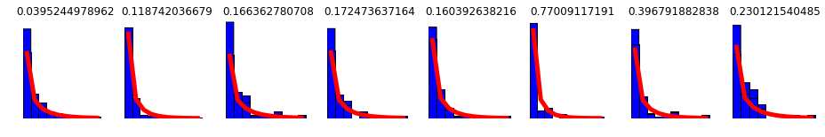

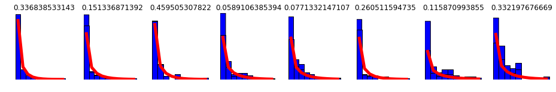

```python
D = np.zeros(2*longTracks.size)
localizationVariance = np.zeros(2*longTracks.size)
varianceD = np.zeros(2*longTracks.size)
SNR = np.zeros(2*longTracks.size)
p = np.zeros(2*longTracks.size)
X2 = np.zeros(2*longTracks.size)
plt.figure(figsize=(16,2))
for i in np.arange(0,longTracks.size):
    plt.subplot(1,8,i)
    x = objs_link[0,objs_link[5,:]==longTracks[i]]
    [D[i], localizationVariance[i], varianceD[i], SNR[i]], Pxk = cveD.cveD(x,dt, scale)
    theoryPxk = cveD.theoryP(D[i], dt, localizationVariance[i], Pxk.size)
    n, bins, patches = plt.hist(Pxk/theoryPxk, 10, normed=True)
    p[i], X2[i] = cveD.gammaChiSquared(n,bins)
    plt.title(p[i])
    plt.axis('off')

plt.figure(figsize=(16,2))
for i in np.arange(0,longTracks.size):
    plt.subplot(1,8,i)
    y = objs_link[1,objs_link[5,:]==longTracks[i]]
    [D[i+longTracks.size], localizationVariance[i+longTracks.size], varianceD[i+longTracks.size], SNR[i+longTracks.size]], Pxk = cveD.cveD(y,dt, scale)
    theoryPxk = cveD.theoryP(D[i+longTracks.size], dt, localizationVariance[i+longTracks.size], Pxk.size)
    n, bins, patches = plt.hist(Pxk/theoryPxk, 10, normed=True)
    p[i+longTracks.size], X2[i+longTracks.size] = cveD.gammaChiSquared(n,bins)
    plt.title(p[i+longTracks.size])
    plt.axis('off')
```

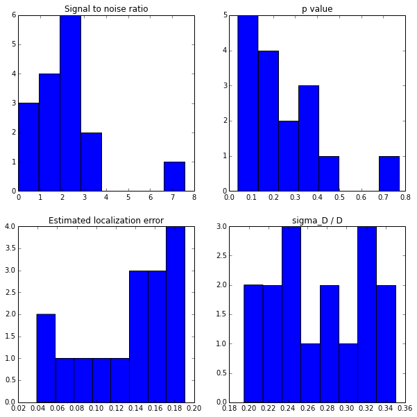

```python
plt.figure(figsize=(10,10))
plt.subplot(2,2,1)
plt.hist(np.nan_to_num(SNR),8)
plt.title('Signal to noise ratio')
plt.subplot(2,2,2)
plt.title('p value')
plt.hist(p,8)
plt.subplot(2,2,3)
plt.hist(np.sqrt(np.abs(localizationVariance)),8)
plt.title('Estimated localization error')
plt.subplot(2,2,4)
plt.hist(np.sqrt(varianceD)/D,8)
plt.title('sigma_D / D')
plt.show()
```

Since there are fewer beads in this video, I will be a little less strict in what to keep, using tracks with SNR>1 and p<0.3

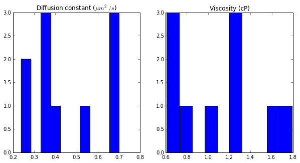

```
(0.45721070948005293, 1.0780570209208231)
0.50736599429
```

```python
keepers = np.logical_and(np.nan_to_num(SNR)>1, p<0.3)
keepDeez = D[keepers]
plt.figure(figsize=(10,5))
plt.subplot(1,2,1)
plt.hist(keepDeez,10)
plt.title(r'Diffusion constant ($\mu m^2 / s$)')
plt.subplot(1,2,2)
plt.hist(cveD.D2eta(keepDeez,1.02/2,25),10)
plt.title('Viscosity (cP)')
plt.show()
print(np.mean(keepDeez),np.mean(cveD.D2eta(keepDeez,1.02/2,25)))
print(np.sqrt(np.mean(varianceD[keepers]))/np.mean(keepDeez**2))
```

I'm calling this a successful test of the function library `cved.py`